# Projet Clustering et réduction de dimensions (Ensai, 3A)

Thomas Guinhut et Eulalie Delaune

Février 2026

```r
bdd <- read.csv2("creation.csv") %>%
  rename(
    departement = Departement,
    industrie_2013 = X2013_C,
    energie_2013 = X2013_D,
    environnement_2013 = X2013_E,
    construction_2013 = X2013_F,
    commerce_2013 = X2013_G,
    transport_2013 = X2013_H,
    hotellerie_2013 = X2013_I,
    information_2013 = X2013_J,
    finance_2013 = X2013_K,
    immobilier_2013 = X2013_L,
    science_2013 = X2013_M,
    administration_2013 = X2013_N,
    enseignement_2013 = X2013_P,
    sante_2013 = X2013_Q,
    culture_2013 = X2013_R,
    services_2013 = X2013_S,
    industrie_2023 = X2023_C,
    energie_2023 = X2023_D,
    environnement_2023 = X2023_E,
    construction_2023 = X2023_F,
    commerce_2023 = X2023_G,
    transport_2023 = X2023_H,
    hotellerie_2023 = X2023_I,
    information_2023 = X2023_J,
    finance_2023 = X2023_K,
    immobilier_2023 = X2023_L,
    science_2023 = X2023_M,
    administration_2023 = X2023_N,
    enseignement_2023 = X2023_P,
    sante_2023 = X2023_Q,
    culture_2023 = X2023_R,
    services_2023 = X2023_S
  )
```

```r
glimpse(bdd)
```

```
## Rows: 101
## Columns: 33
## $ departement         <chr> "Ain", "Aisne", "Allier", "Alpes-de-Haute-Provence…
## $ industrie_2013      <int> 167, 99, 76, 71, 363, 140, 64, 72, 62, 131, 85, 25…
## $ energie_2013        <int> 34, 8, 8, 2, 10, 45, 5, 15, 18, 24, 15, 80, 169, 6…
## $ environnement_2013  <int> 16, 8, 11, 2, 23, 3, 8, 1, 13, 13, 2, 50, 16, 10, …
## $ construction_2013   <int> 494, 335, 236, 220, 1905, 338, 185, 230, 183, 429,…
## $ commerce_2013       <int> 826, 657, 505, 263, 1842, 466, 482, 230, 442, 761,…
## $ transport_2013      <int> 39, 26, 11, 8, 237, 12, 15, 8, 11, 13, 12, 62, 219…
## $ hotellerie_2013     <int> 132, 97, 91, 72, 318, 143, 70, 63, 44, 166, 102, 1…
## $ information_2013    <int> 108, 70, 41, 38, 460, 60, 33, 29, 54, 61, 35, 301,…
## $ finance_2013        <int> 35, 20, 12, 7, 134, 6, 12, 7, 11, 23, 9, 43, 84, 2…
## $ immobilier_2013     <int> 36, 48, 23, 12, 291, 41, 20, 28, 19, 21, 49, 163, …
## $ science_2013        <int> 350, 168, 144, 97, 1590, 181, 71, 101, 153, 211, 1…
## $ administration_2013 <int> 207, 106, 73, 74, 1083, 110, 55, 64, 86, 146, 59, …
```

[output cut: 20 more lines]

# Question 1 : pourquoi faire une AFM ?

A la lecture des données, on constate que la structure de la base de données se prête à une AFM. En effet, il y a deux périodes temporelles distinctes, formant ainsi deux groupes, qu’on peut étudier simultanément lors d’une AFM. Puisque nous disposons de nombreuses variables aux deux périodes temporelles, réduire la dimension des données semble intéressant.

```r
bdd_analyse <- bdd %>%
  pivot_longer(cols = -departement) %>%
  mutate(annee = substr(name, nchar(name) - 3, nchar(name)), .before = name,
         name = sub("_.*", "", name)) %>%
  mutate(secteur = case_when(
    name == "industrie" ~ "Industrie",
    name == "energie" ~ "Énergie",
    name == "environnement" ~ "Environnement",
    name == "construction" ~ "Construction",
    name == "commerce" ~ "Commerce",
    name == "transport" ~ "Transport",
    name == "hotellerie" ~ "Hôtellerie",
    name == "information" ~ "Information",
    name == "finance" ~ "Finance",
    name == "immobilier" ~ "Immobilier",
    name == "science" ~ "Science",
    name == "administration" ~ "Administration",
    name == "enseignement" ~ "Enseignement",
    name == "sante" ~ "Santé",
    name == "culture" ~ "Culture",
    name == "services" ~ "Services"
  ))
```

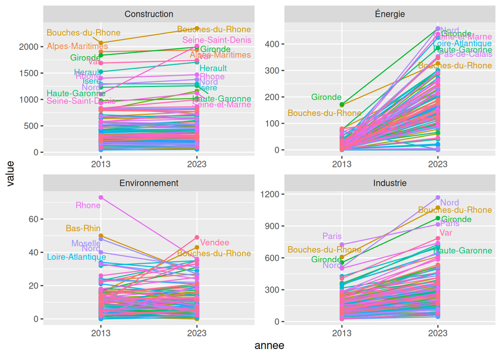

```r
creer_graphiques_par_groupe <- function(bdd_analyse, bdd_labels_left,
                                        bdd_labels_right, n_par_graphique = 8,
                                        maxoverlap) {

  bdd_labels_left <- bdd_analyse %>%
  filter(annee == min(annee))

  bdd_labels_right <- bdd_analyse %>%
    filter(annee == max(annee))

  variables <- unique(bdd_analyse$secteur)

  n_graphiques <- ceiling(length(variables) / n_par_graphique)

  liste_graphiques <- list()

  for (i in 1:n_graphiques) {

    debut <- (i - 1) * n_par_graphique + 1
    fin <- min(i * n_par_graphique, length(variables))

    vars_groupe <- variables[debut:fin]

    g <- ggplot(bdd_analyse %>% filter(secteur %in% vars_groupe),
                aes(x = annee,
                    y = value,
                    group = departement,
                    col = departement)) +
      geom_line() +
      geom_point() +

      geom_text_repel(data = bdd_labels_left %>% filter(secteur %in% vars_groupe),
                      aes(label = departement),
                      hjust = 1,
                      size = 3,
                      direction = "y",
                      max.overlaps = maxoverlap,
                      show.legend = FALSE) +
      geom_text_repel(data = bdd_labels_right %>% filter(secteur %in% vars_groupe),
                      aes(label = departement),
                      hjust = -0.1,
                      size = 3,
                      direction = "y",
                      max.overlaps = maxoverlap,
                      show.legend = FALSE) +

      facet_wrap(~ secteur, nrow = 4, ncol = 2, scales = "free") +
      guides(col = "none")

    liste_graphiques[[i]] <- g
  }

  return(liste_graphiques)
}

graphiques <- creer_graphiques_par_groupe(bdd_analyse, n_par_graphique = 4,
                                          maxoverlap = 10)

graphiques[[1]]
```

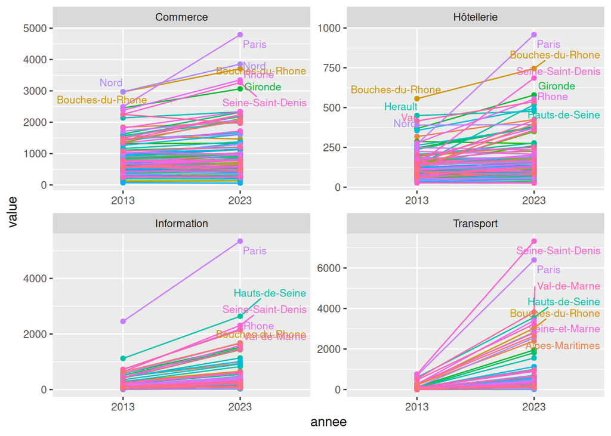

```r
graphiques[[2]]
```

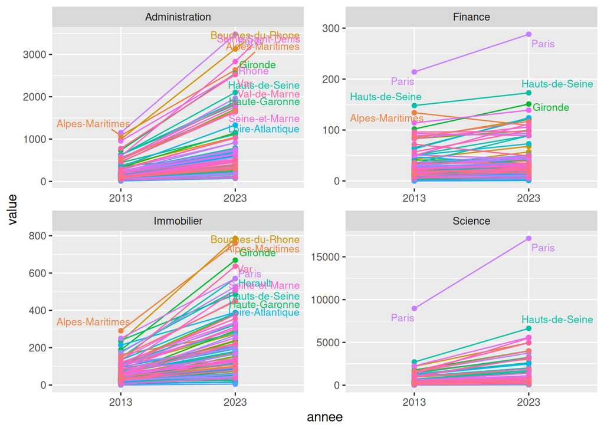

```r
graphiques[[3]]
```

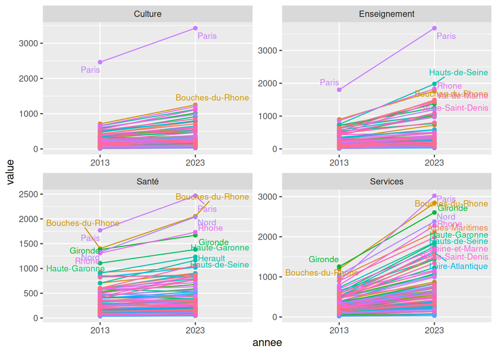

```r
graphiques[[4]]
```

On observe la prédominance de Paris dans certains secteurs d’activité spécialisés comme la finance, la culture, l’enseignement, la recherche, l’information et la communication. D’autres départements se démarquent dans quelques secteurs, comme la Seine-Saint-Denis pour les transports (on suppose du fait de l’aéroport Charles-de-Gaulle), le Nord pour l’industrie (qui est historiquement une activité importante pour ce département) et les Bouches-du-Rhône pour la construction, là où l’immobilier y est également important (supposément pour l’attrait suscité par ce département balnéaire).

Pour s’extirper du problème des individus atypiques, on propose de calculer, pour chaque année, la part de chaque secteur dans chaque département.

```r
calculer_proportions <- function(data) {

  cols_2013 <- grep("2013$", names(bdd), value = TRUE)
  cols_2023 <- grep("2023$", names(bdd), value = TRUE)

  data_2013_prop <- data %>%
    select(departement, all_of(cols_2013)) %>%
    mutate(
      total_2013 = rowSums(select(., -departement)),
      across(all_of(cols_2013), ~ . / total_2013 * 100, .names = "{.col}_prop")
    ) %>%
    select(departement, ends_with("_prop")) %>%
    rename_with(~ gsub("_prop", "", .), ends_with("_prop"))

  data_2023_prop <- data %>%
    select(departement, all_of(cols_2023)) %>%
    mutate(
      total_2023 = rowSums(select(., -departement)),
      across(all_of(cols_2023), ~ . / total_2023 * 100, .names = "{.col}_prop")
    ) %>%
    select(departement, ends_with("_prop")) %>%
    rename_with(~ gsub("_prop", "", .), ends_with("_prop"))

  data_prop <- left_join(data_2013_prop, data_2023_prop, by = "departement")

  return(data_prop)
}

bdd_prop <- calculer_proportions(bdd)

bdd_prop_analyse <- bdd_prop %>%
  pivot_longer(cols = -departement) %>%
  mutate(annee = substr(name, nchar(name) - 3, nchar(name)), .before = name,
         name = sub("_.*", "", name)) %>%
  mutate(secteur = case_when(
    name == "industrie" ~ "Industrie",
    name == "energie" ~ "Énergie",
    name == "environnement" ~ "Environnement",
    name == "construction" ~ "Construction",
    name == "commerce" ~ "Commerce",
    name == "transport" ~ "Transport",
    name == "hotellerie" ~ "Hôtellerie",
    name == "information" ~ "Information",
    name == "finance" ~ "Finance",
    name == "immobilier" ~ "Immobilier",
    name == "science" ~ "Science",
    name == "administration" ~ "Administration",
    name == "enseignement" ~ "Enseignement",
    name == "sante" ~ "Santé",
    name == "culture" ~ "Culture",
    name == "service" ~ "Services"
  ))
```

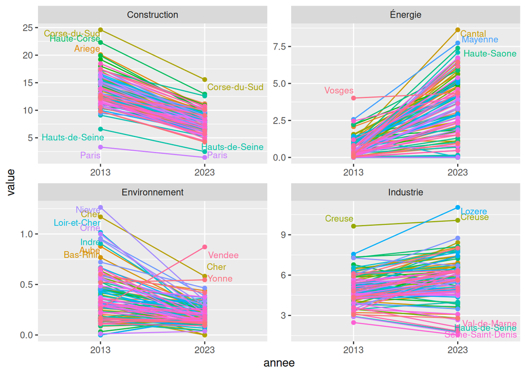

```r
graphiques_prop <- creer_graphiques_par_groupe(bdd_prop_analyse,
                                               bdd_labels_left,
                                               bdd_labels_right,
                                               n_par_graphique = 4,
                                               maxoverlap = 10)

graphiques_prop[[1]]
```

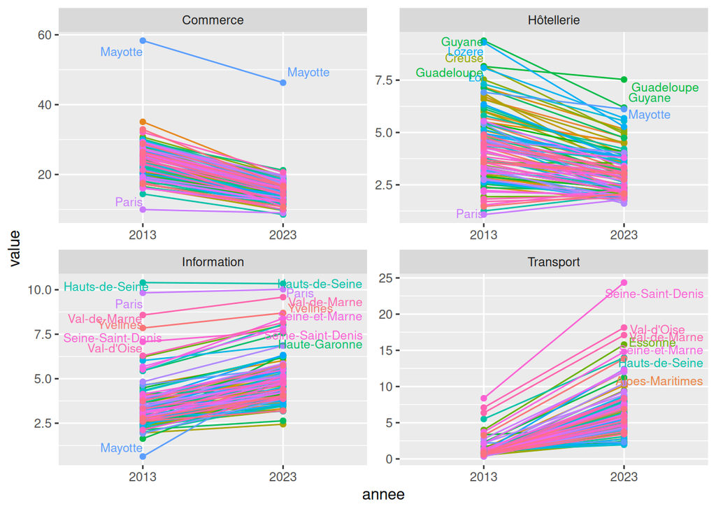

```r
graphiques_prop[[2]]
```

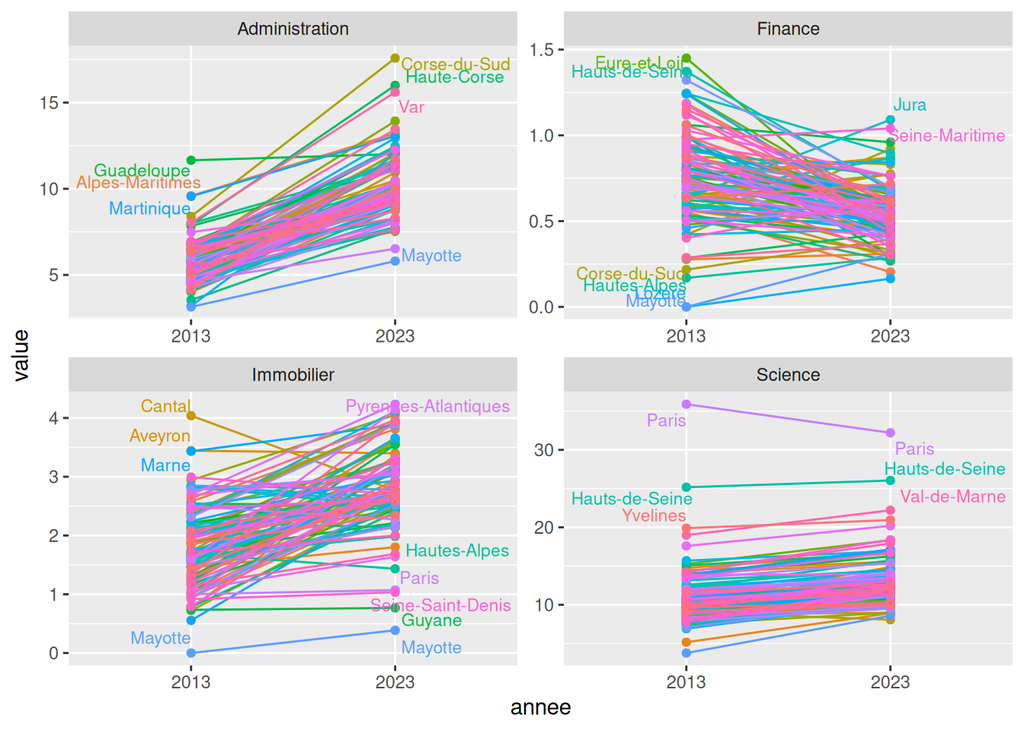

```r
graphiques_prop[[3]]
```

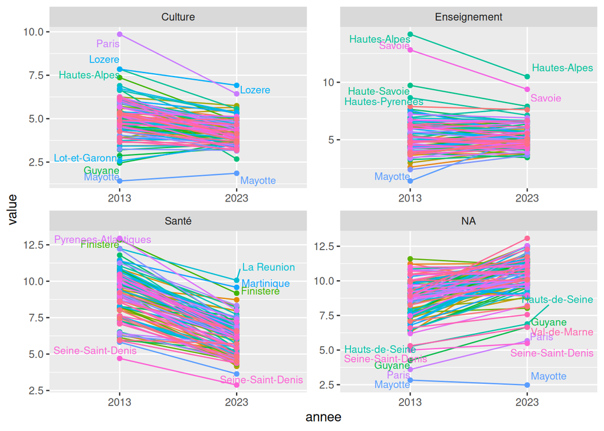

```r
graphiques_prop[[4]]
```

```r
graphique_comparaison_dept <- function(bdd_analyse, departements,
                                       maxoverlap = 4) {

  bdd_filtre <- bdd_analyse %>% filter(departement %in% departements)

  bdd_labels <- bdd_filtre %>%
    group_by(departement, secteur) %>%
    filter(annee == max(annee))

  g <- ggplot(bdd_filtre,
              aes(x = annee,
                  y = value,
                  group = secteur,
                  col = secteur)) +
    geom_line() +
    geom_point() +

    geom_text_repel(data = bdd_labels,
                    aes(label = secteur),
                    hjust = -0.1,
                    size = 3,
                    direction = "y",
                    max.overlaps = maxoverlap,
                    show.legend = FALSE) +

    facet_wrap(~ departement, nrow = 1, ncol = 2) +
    guides(col = "none")

  return(g)
}
```

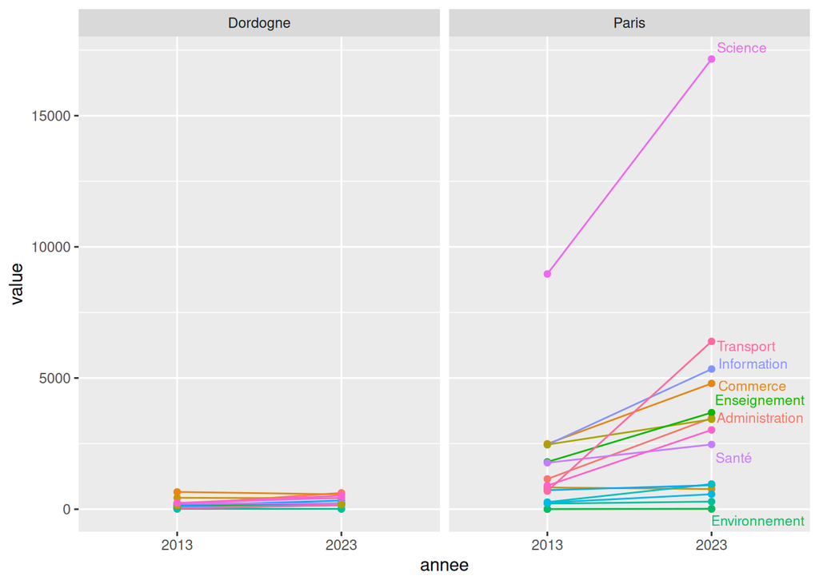

```r
graphique_comparaison_dept(bdd_analyse, c("Paris", "Dordogne"))
```

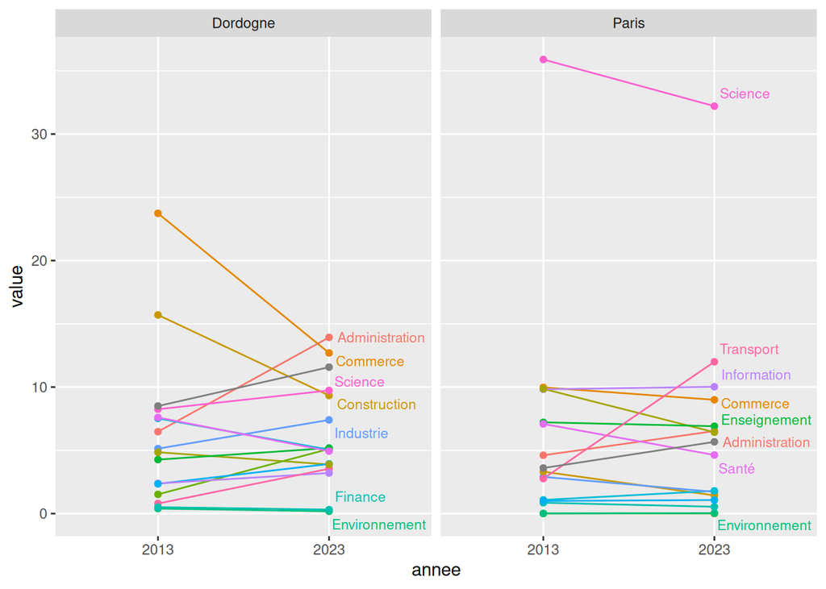

```r
graphique_comparaison_dept(bdd_prop_analyse, c("Paris", "Dordogne"))
```

Sur cet exemple, nous voyons que lorsque l’on compare un département-capitale et un département très rural, il est préférable d’utiliser les proportions de chaque secteur dans l’économie locale. Autrement, l’analyse se limitera à un focus sur le département qui produit le plus de tout du fait de sa structure, historique, notamment en terme d’effectif de sa population.

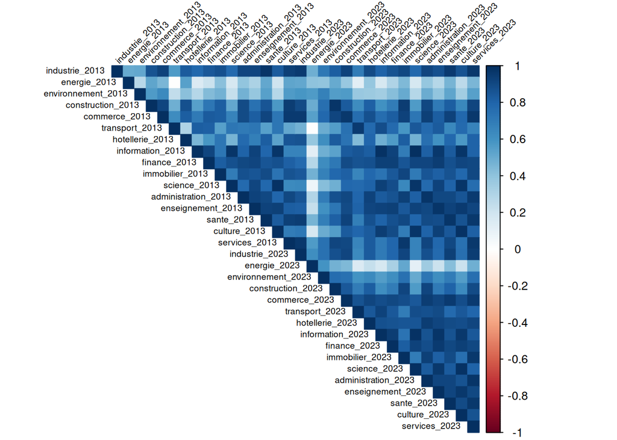

```r
corrplot::corrplot(cor(
  bdd[,colnames(bdd) != "departement"],
                         use = "complete.obs"), method = "color",
  type = "upper", tl.col = "black", tl.srt = 45, tl.cex = 0.6)
```

De même, cette première cartographie des corrélations sur les données brutes apparaît peu lisible. En effet, toutes les variables ou presque sont fortement corrélées. Cela est dû au fait que certains départements produisent beaucoup et d’autres moins. Ainsi, dans un département où il y a des nombreuses créations d’entreprises en énergie, il y en aura également beaucoup dans d’autres secteurs comme la finance ou l’environnement. Cela signifie qu’il s’agit d’un département plutôt porteur en termes de créations d’entreprises. Les corrélations entre les deux périodes sont difficiles à observer ici. Pour mieux distinguer les corrélations, nous les observons donc sur les variables proportionnelles.

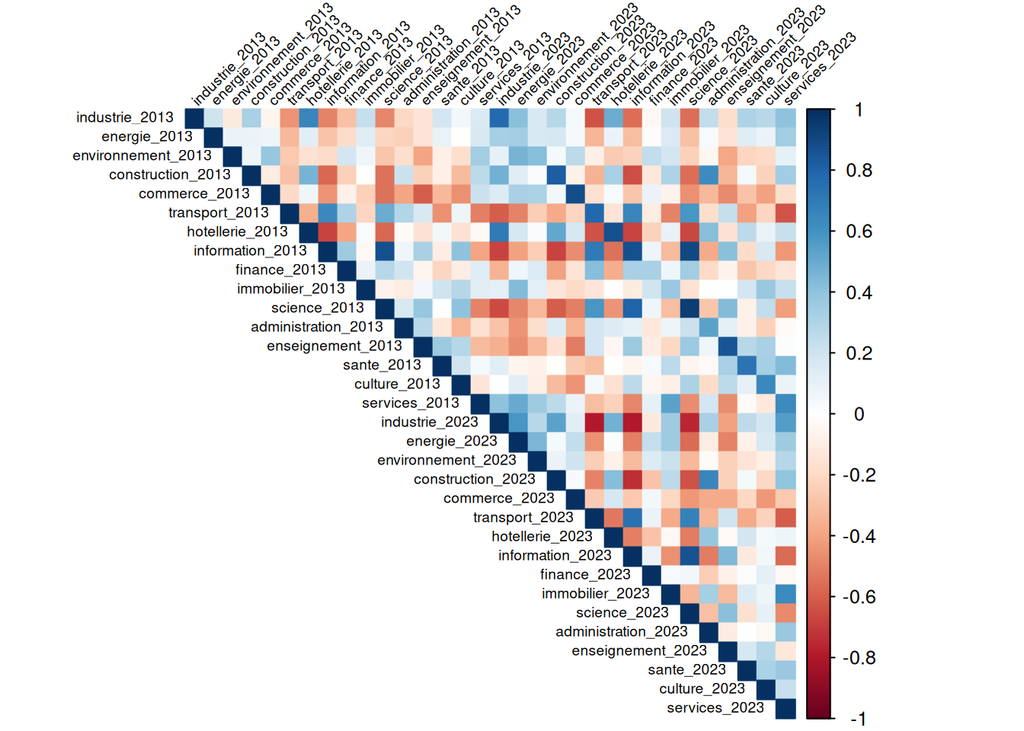

```r
corrplot::corrplot(cor(
  bdd_prop[,colnames(bdd_prop) != "departement"],
                         use = "complete.obs"), method = "color",
  type = "upper", tl.col = "black", tl.srt = 45, tl.cex = 0.6)
```

La cartographie des corrélations entre la part des secteurs au sein des créations d’entreprises par département semble donner plus d’informations. On constate tout d’abord une corrélation plutôt marquée entre les secteurs de création d’une période à l’autre. On peut également voir que certains secteurs sont corrélés négativement sur les deux périodes, comme l’industrie avec le transport, l’information et la science.

Finalement, on constate des corrélations très distinctes entre les secteurs. Une AFM semble ainsi particulièrement pertinente pour réduire l’ensemble de ces informations.

# Question 2 : mise en oeuvre de l’AFM

## Sur les données brutes

```r
bdd_mfa <- bdd
rownames(bdd_mfa) <- bdd_mfa$departement
bdd_mfa$departement <- NULL
```

```r
res.MFA <- MFA(bdd_mfa,
               group = c(16,16),
               type = rep("c", 2),
               ncp = 5,
               name.group = c("2013", "2023"),
               graph = F)
```

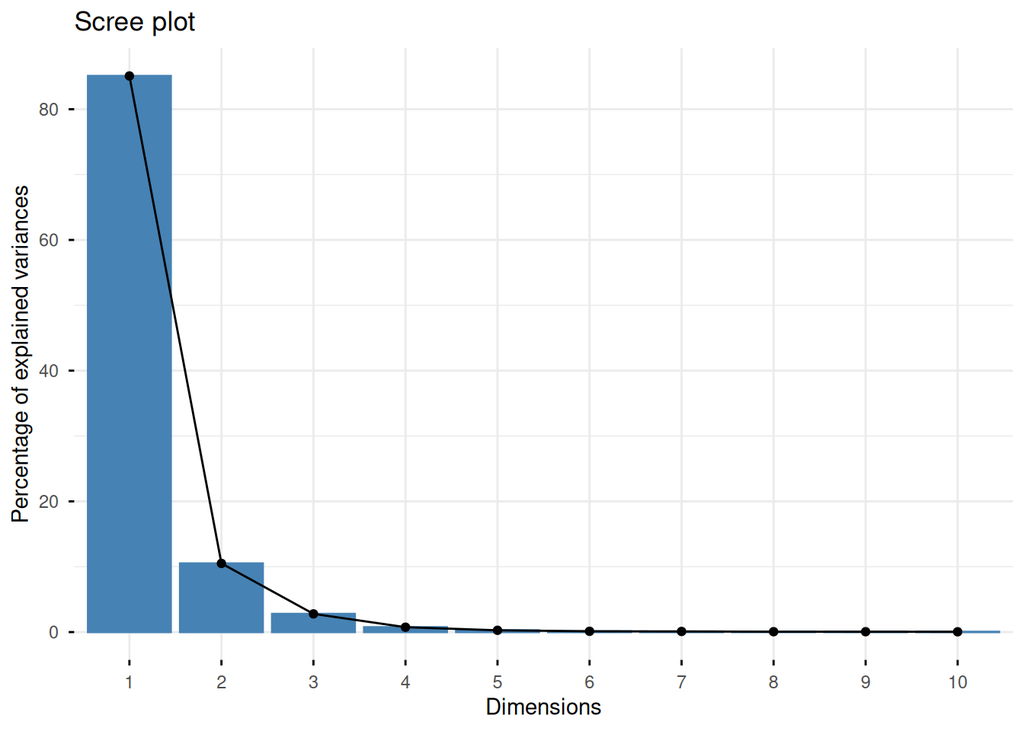

```r
fviz_screeplot(res.MFA)
```

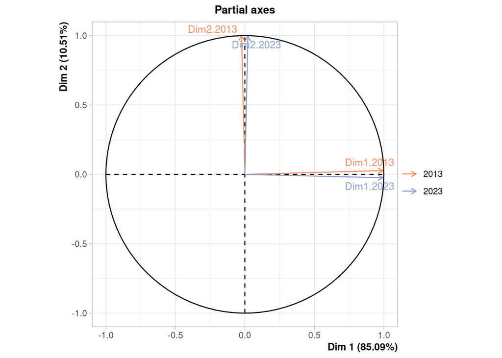

```r
plot(res.MFA, choix = "axes", axes = c(1, 2),
     habillage = "group",
     palette = brewer.pal(3, "Set2"),
     repel = TRUE,
     cex = 0.9)
```

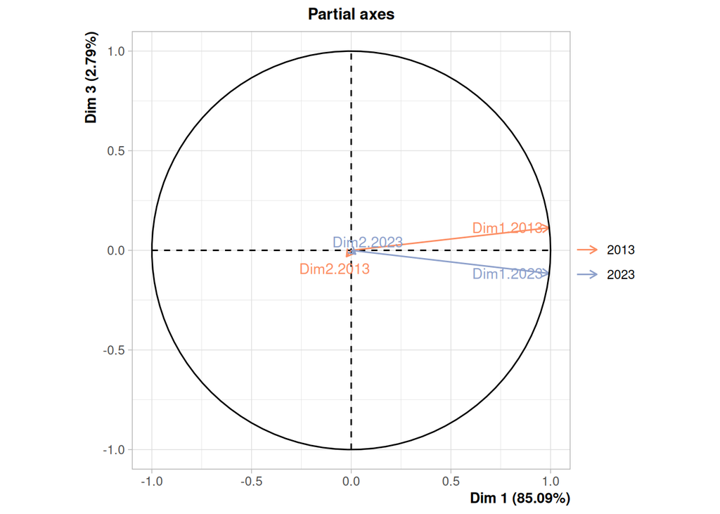

```r
plot(res.MFA, choix = "axes", axes = c(1, 3),
     habillage = "group",
     palette = brewer.pal(3, "Set2"),
     repel = TRUE,
     cex = 0.9)
```

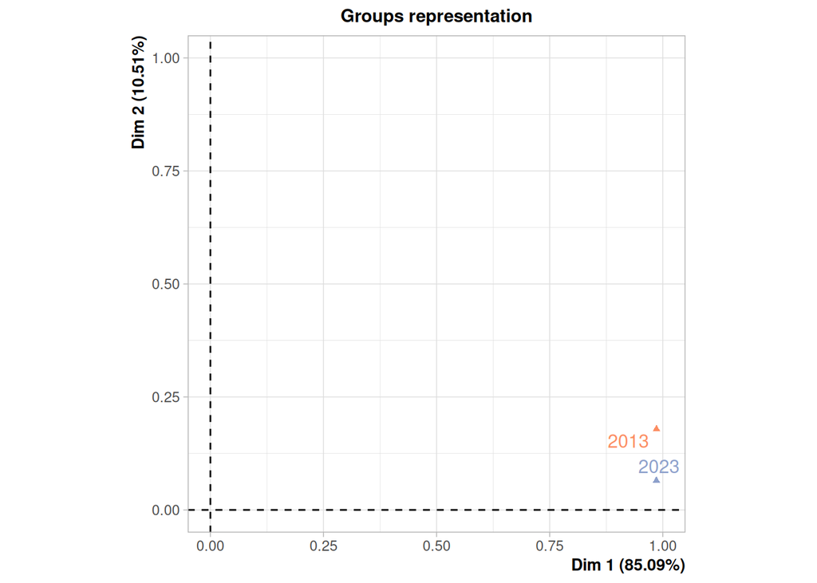

```r
plot(res.MFA, choix = "group", palette = brewer.pal(3, "Set2"))
```

Les deux premiers axes permettent de capter 95% de l’inertie du nuage des individus partiels, et les composantes construites pour 2013 et 2023 sont très proches l’une de l’autre, synonyme d’un référentiel commun pour faire une anaylse de ces deux photographies de l’activité économique.

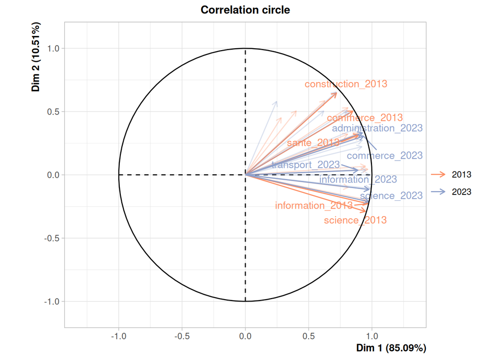

```r
plot(res.MFA, choix = "var", axes = c(1, 2),
     habillage = "group",
     palette = brewer.pal(3, "Set2"),
     repel = TRUE,
     cex = 0.9,
     select = "contrib 10")
```

La première composante reflète un effet taille. La deuxième n’est pas marquée par beaucoup de corrélations. Il semble plutôt difficile d’interpréter les projections des variables, car elles sont globalement toutes rapprochées. On peut constater que des variables comme la construction et l’information et les sciences s’opposent sur l’axe 2, qui, cependant, porte seulement 10% de l’inertie.

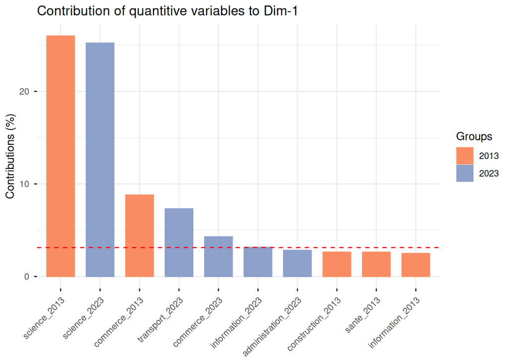

```r
fviz_contrib(res.MFA, choice = "quanti.var", axes = 1, top = 10,
             palette = brewer.pal(3, "Set2")[2:3])
```

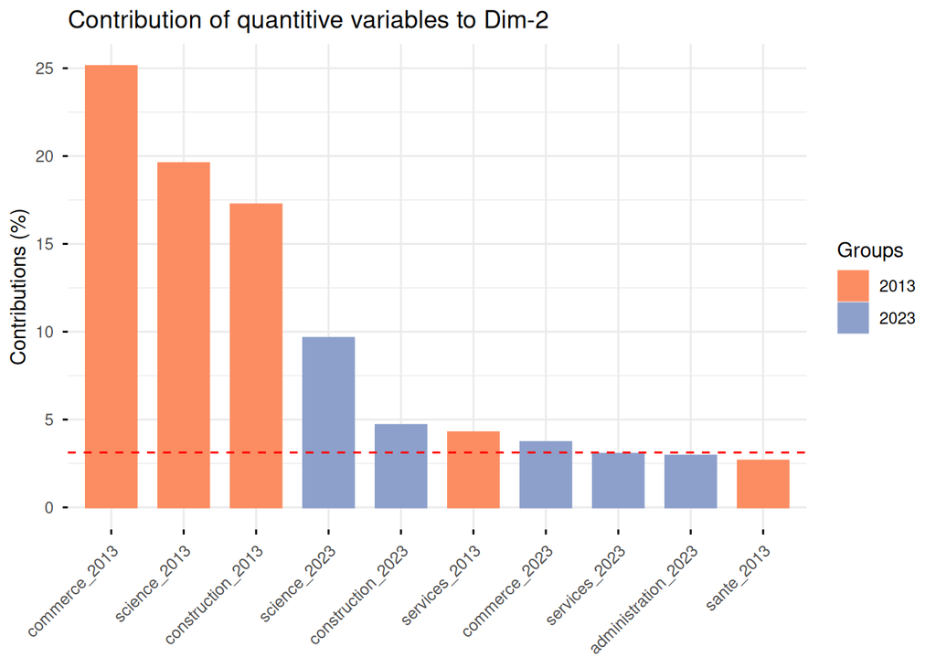

```r
fviz_contrib(res.MFA, choice = "quanti.var", axes = 2, top = 10,
             palette = brewer.pal(3, "Set2")[2:3])
```

Certains secteurs prédominent la construction des axes : le commerce, la science, la construction… Ceci traduit un effet taille. En effet, ces secteurs connaissent beaucoup plus de créations d’entreprises que les autres, ce qui va naturellement influencer énormément la construction des axes de l’AFM. Nous pourrions normaliser les données, mais nous préférons nous intéresser plus tard à la proportion des secteurs au sein des créations d’entreprises de chaque département.

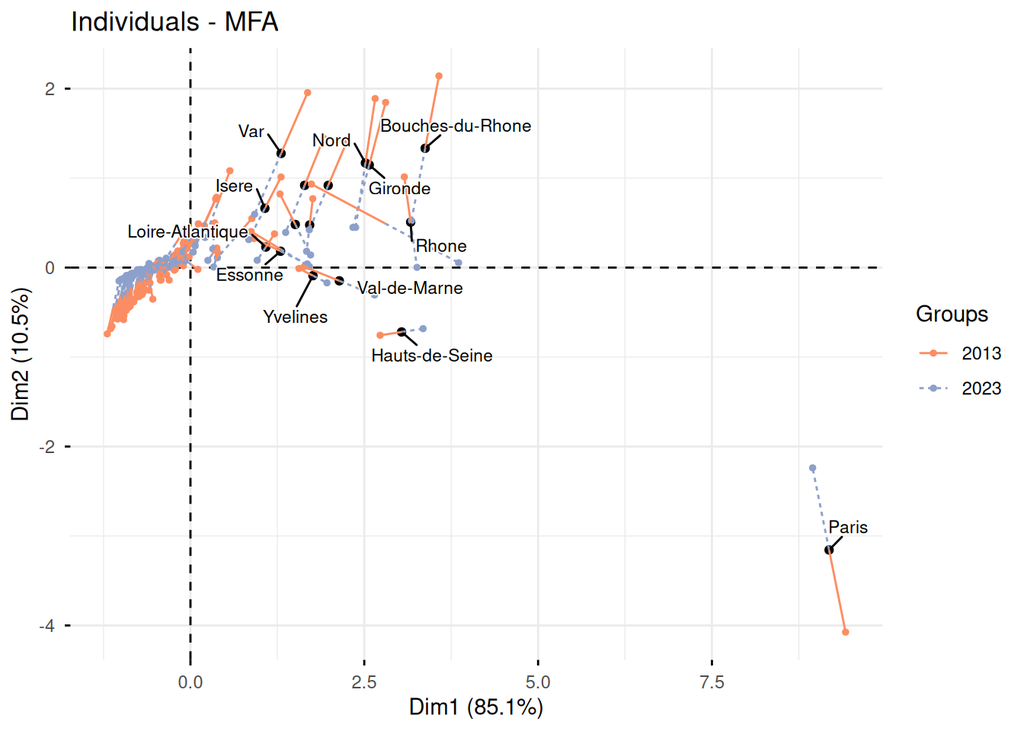

```r
fviz_mfa_ind(res.MFA, partial = "all", invisible = "ind.sup",
             repel = TRUE, labelsize = 3,
             select.ind = list(cos2 = 0.8,
                               name = as.data.frame(res.MFA$ind$coord) %>%
                                 filter(Dim.1 > 1) %>%
                                 rownames()),
             geom = "point",
             palette = brewer.pal(3, "Set2")[2:3]) +
  geom_text_repel(aes(label = name), size = 3,
                  box.padding = 0.5,
                  bg.color = "white",
                  bg.r = 0.1)
```

Paris, qui est un département particulièrement productif, prend des valeurs très élevées sur l’axe 1. Ainsi, sa présence altère la visualisation des autres départements, qui sont tous regroupés. Restent également visibles distinctement les autres départements les plus peuplés du pays : ceux de la région Île-de-France, du Rhône, de la Gironde, des Bouches-du-Rhône et du Nord.

Le reste des départements n’étant pas visibles tellement ils sont contonnés autours des mêmes coordonées factorielles, nous proposons d’appliquer la même technique d’analyse sur la base des proportions.

## Sur les proportions

```r
bdd_prop_mfa <- bdd_prop
rownames(bdd_prop_mfa) <- bdd_prop_mfa$departement
bdd_prop_mfa$departement <- NULL
```

```r
res.MFAprop <- MFA(bdd_prop_mfa,
                   group = c(16,16),
                   type = rep("c", 2),
                   ncp = 5,
                   name.group = c("2013", "2023"),
                   graph = F)
```

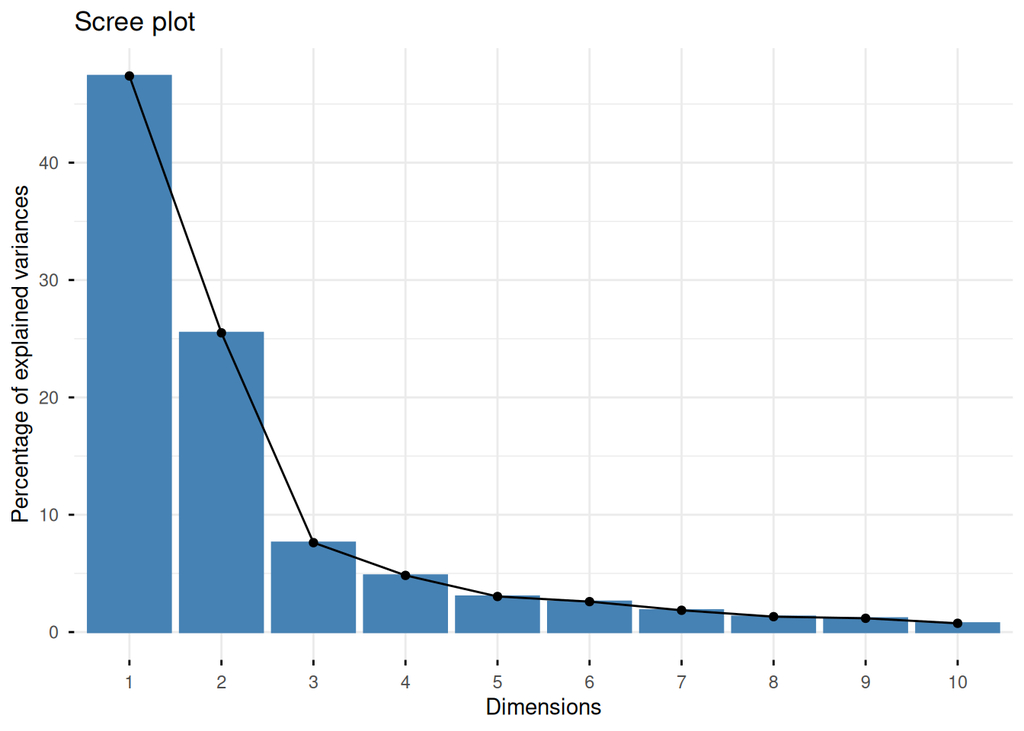

```r
fviz_screeplot(res.MFAprop)
```

Ici, toute l’information n’est pas résumée sur un seul axe mais sur les 3 ou 4 premiers. Ceci semble indiquer un meilleur équilibre.

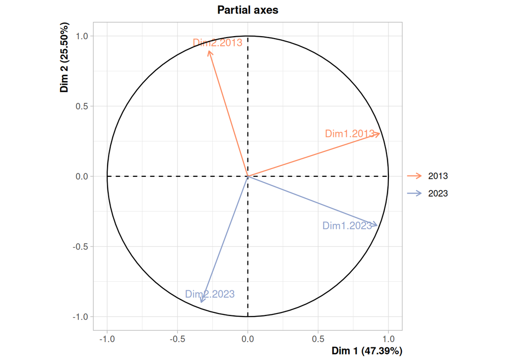

```r
plot(res.MFAprop, choix = "axes", axes = c(1, 2),
     habillage = "group",
     palette = brewer.pal(3, "Set2"),
     repel = TRUE,
     cex = 0.9)
```

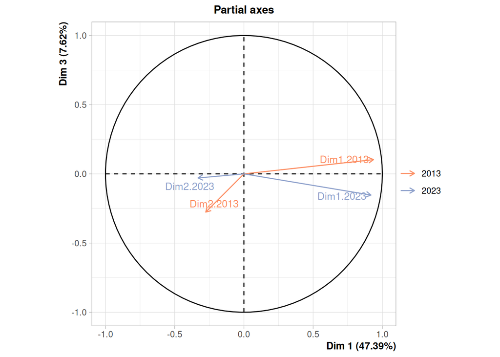

```r
plot(res.MFAprop, choix = "axes", axes = c(1, 3),
     habillage = "group",
     palette = brewer.pal(3, "Set2"),
     repel = TRUE,
     cex = 0.9)
```

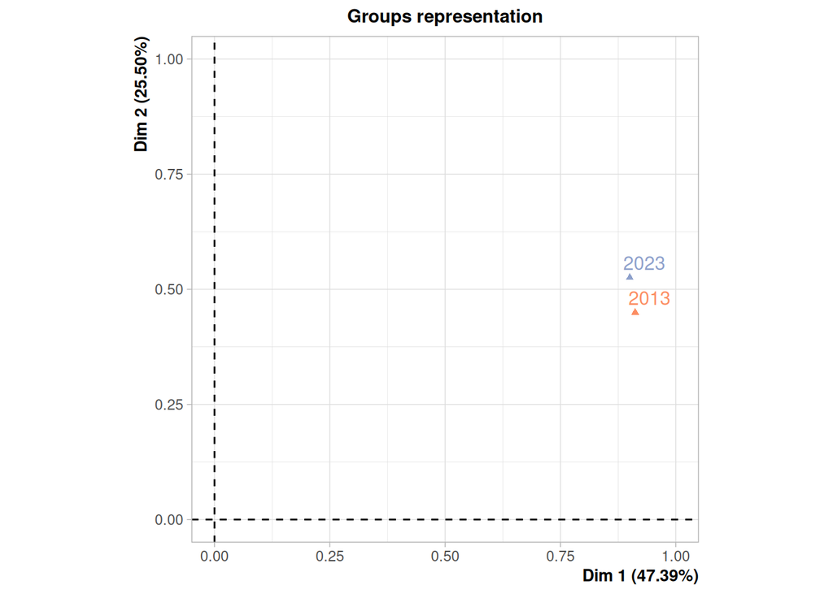

```r
plot(res.MFAprop, choix = "group", palette = brewer.pal(3, "Set2"))
```

Les différentes composantes semblent plutôt bien représentées sur les deux premiers axes, puisqu’elles atteignent les bords du cercle. Elles semblent également avoir un référentiel commun d’une période à l’autre, puisqu’au sens près, elles sont très proches.

En revanche, elles semblent moins bien représentées sur le troisième axe, mais conservent le référentiel commun.

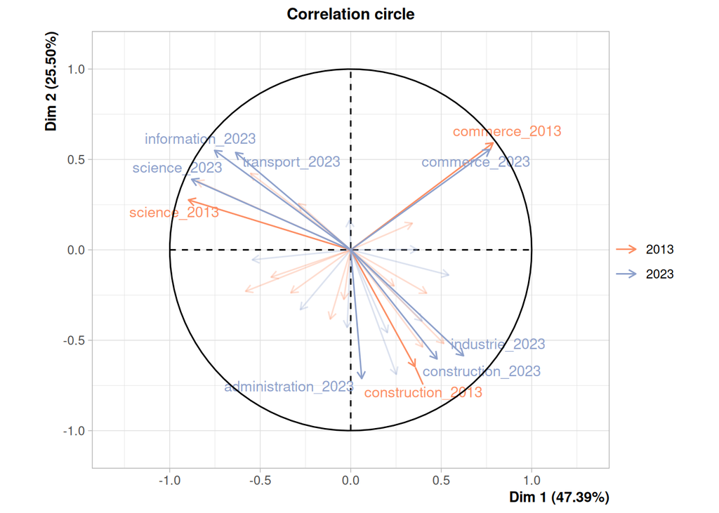

```r
plot(res.MFAprop, choix = "var", axes = c(1, 2),
     habillage = "group",
     palette = brewer.pal(3, "Set2"),
     repel = TRUE,
     cex = 0.9,
     select = "contrib 10")
```

Ce cercle des corrélations nous apporte davantage d’informations sur les dynamiques des secteurs. On y retrouve l’opposition entre les secteurs de l’industrie et de la construction et les secteurs des sciences, de l’information et du transport. Cette opposition est présente sur les deux premiers axes. Le commerce est représenté de manière perpendiculaire aux autres secteurs, ce qui peut laisser suggérer une indépendance.

On peut interpréter l’axe 1 comme opposant les secteurs plus traditionnels (industrie, construction, commerce) aux secteurs plus innovants (information, science) et connaissant une forte croissance aujourd’hui (avec le transport). L’axe 2 peut être perçu comme caractérisant le type de secteur : primaire et secondaire contre tertiaire. Le secteur administratif est plutôt atypique et difficile à corréler aux autres secteurs : il demeure plutôt traditionnel mais relève davantage du tertiaire que du primaire ou du secondaire.

On peut enfin remarquer que les secteurs sont proches d’une période à l’autre.

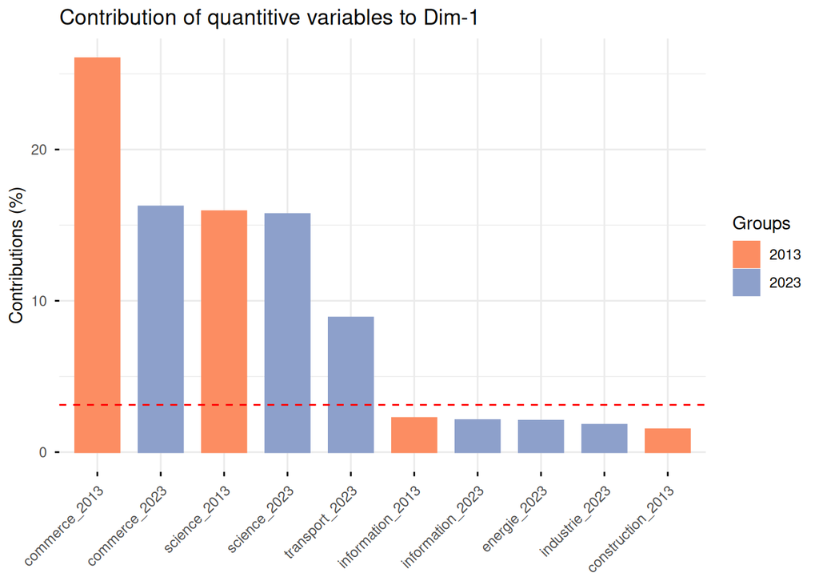

```r
fviz_contrib(res.MFAprop, choice = "quanti.var", axes = 1, top = 10,
             palette = brewer.pal(3, "Set2")[2:3])
```

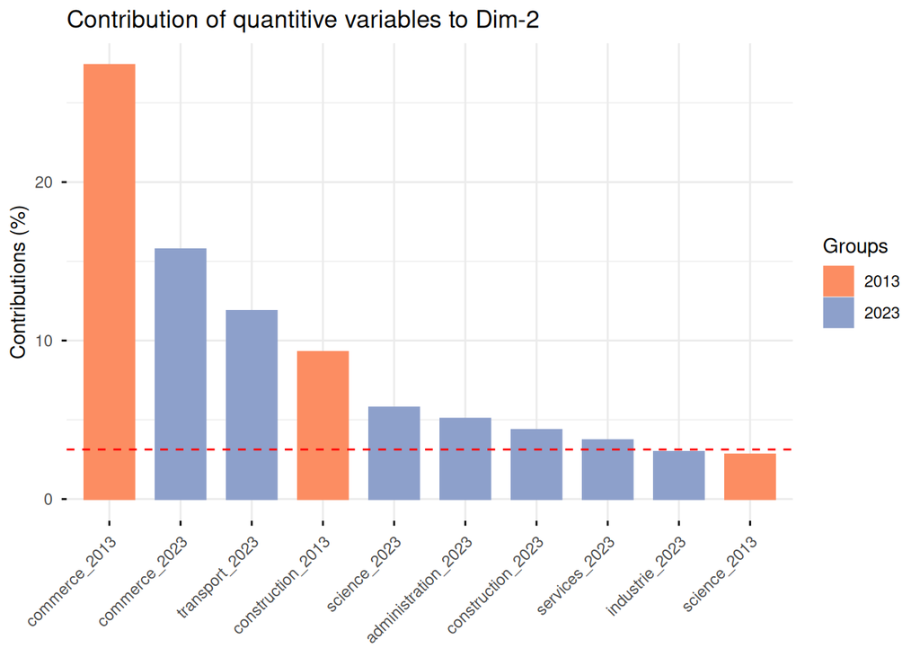

```r
fviz_contrib(res.MFAprop, choice = "quanti.var", axes = 2, top = 10,
             palette = brewer.pal(3, "Set2")[2:3])
```

Cette fois-ci, les contributions sont davantage équilibrées. Le commerce contribue beaucoup à la construction des axes, ainsi que d’autres secteurs comme la science, le transport ou la construction.

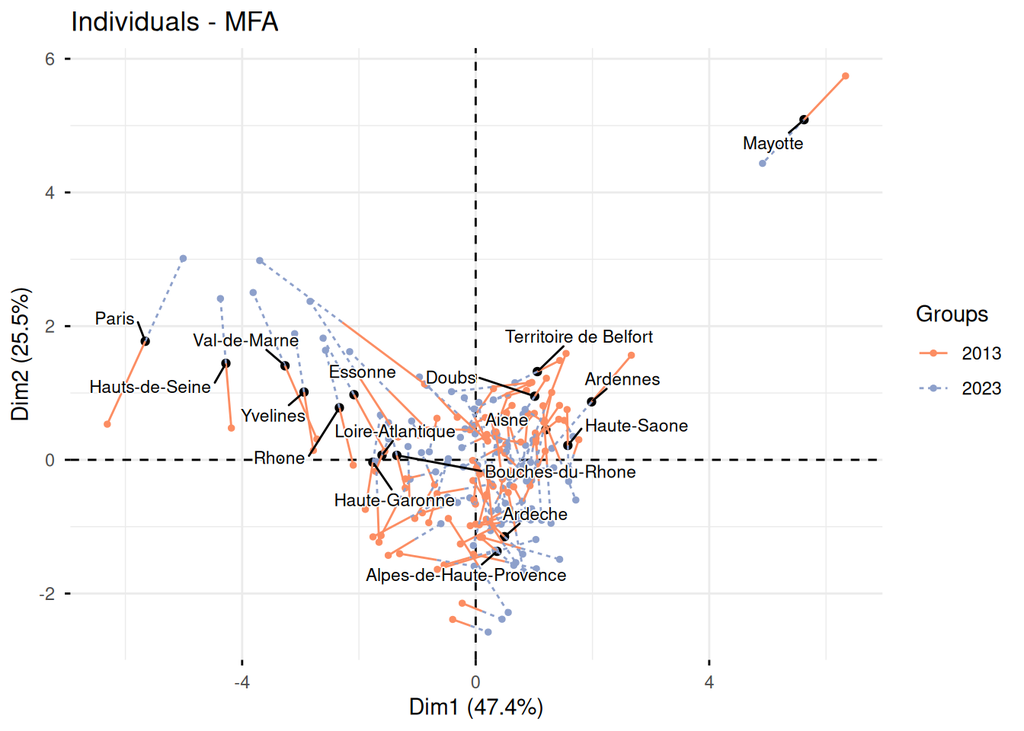

```r
fviz_mfa_ind(res.MFAprop, partial = "all", invisible = "ind.sup",
             repel = TRUE, labelsize = 3,
             select.ind = list(cos2 = 0.8,
                               name = as.data.frame(res.MFAprop$ind$coord) %>%
                                 filter(Dim.1 > 1 | Dim.1 < -1 |
                                          Dim.2 > 1 | Dim.2 < -1) %>%
                                 rownames()),
             geom = "point",
             palette = brewer.pal(3, "Set2")[2:3]) +
  geom_text_repel(aes(label = name), size = 3,
                  box.padding = 0.5,
                  bg.color = "white",
                  bg.r = 0.1)
```

Dans cette configuration, Paris est beaucoup moins atypique et rejoint davantage d’autres départements. De fortes évolutions traduisent un changement de secteur dominant au sein d’un département. On remarque de nombreuses trajectoires similaires. Certaines, avec des traits bleus en haut à droite et des traits orange en bas, reflètent une bascule vers des secteurs très innovants du tertiaire entre 2013 et 2023. C’est le cas des Hauts-de-Seine ou du Val-de-Marne. Pour d’autres département, c’est l’inverse, comme les Alpes-de-Haute-Provence. Enfin, certains départements vont davantage s’éloigner du commerce, ce qui est illustré par des trajectoires comme celles des Ardennes ou du Territoire de Belfort.

## Sur les proportions hors Mayotte

```r
res.MFAprop_horsMayotte <- MFA(bdd_prop_mfa,
                               group = c(16,16),
                               type = rep("c", 2),
                               ncp = 5,
                               ind.sup = which(rownames(bdd_prop_mfa) == "Mayotte"),
                               name.group = c("2013", "2023"),
                               graph = F)
```

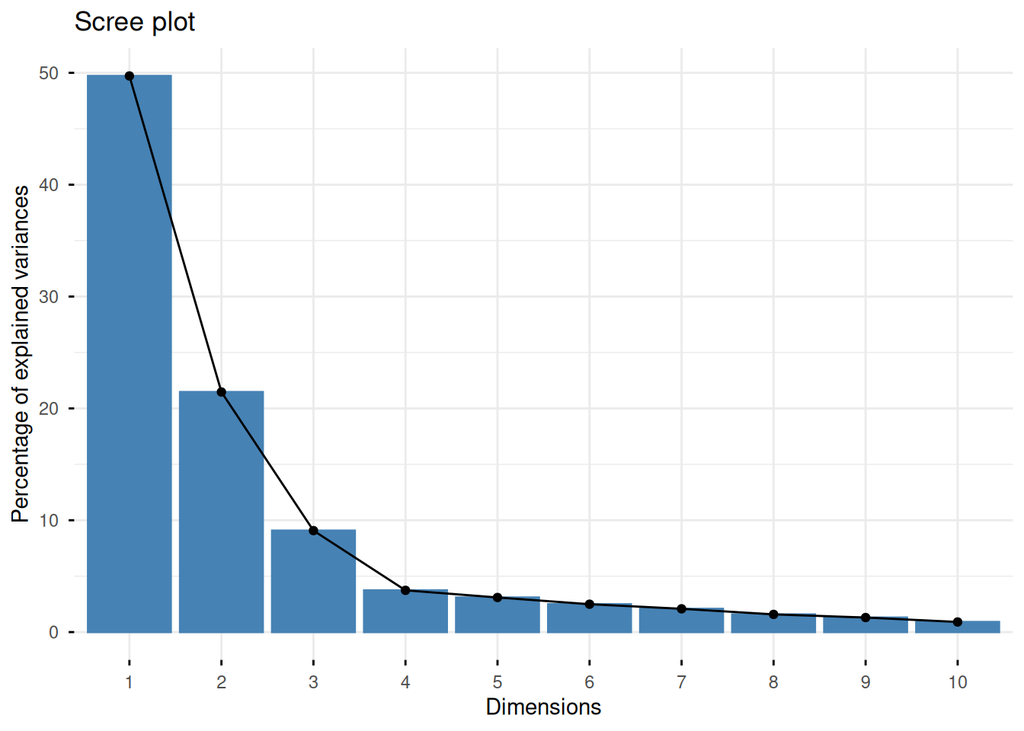

```r
fviz_screeplot(res.MFAprop_horsMayotte)
```

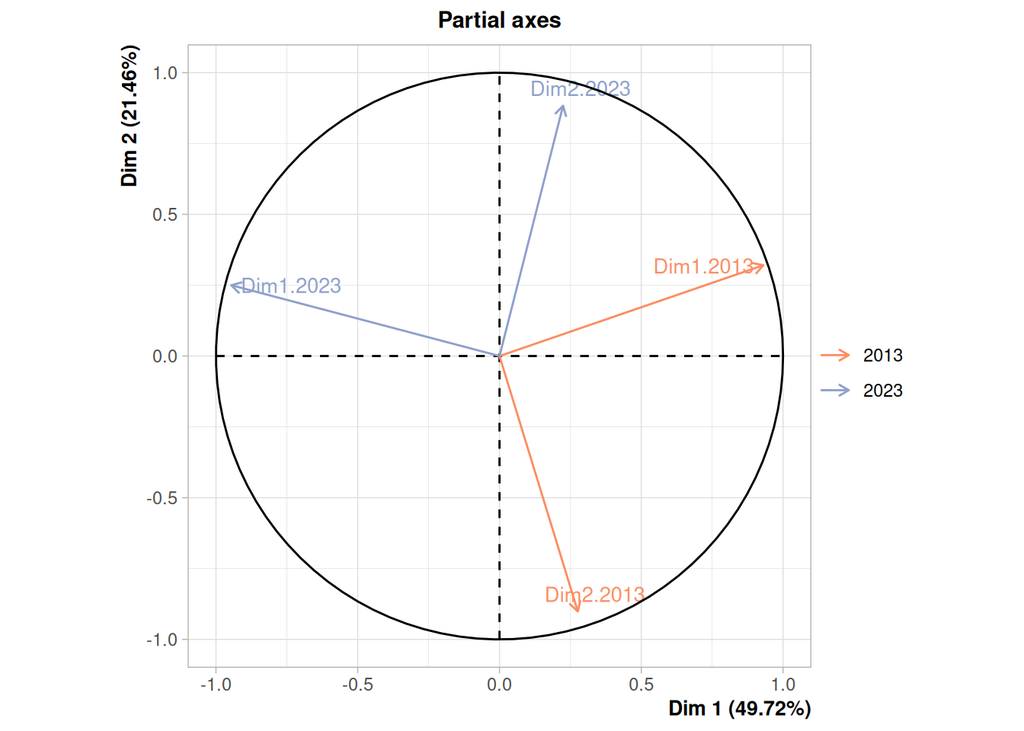

```r
plot(res.MFAprop_horsMayotte, choix = "axes", axes = c(1, 2),
     habillage = "group",
     palette = brewer.pal(3, "Set2"),
     repel = TRUE,
     cex = 0.9)
```

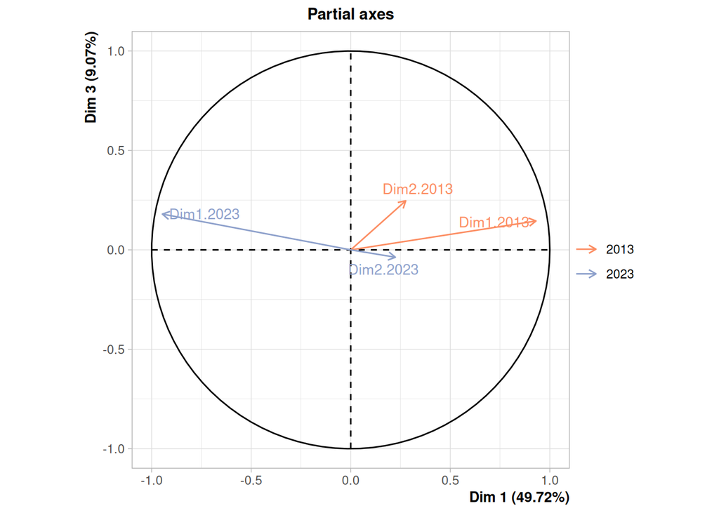

```r
plot(res.MFAprop_horsMayotte, choix = "axes", axes = c(1, 3),
     habillage = "group",
     palette = brewer.pal(3, "Set2"),
     repel = TRUE,
     cex = 0.9)
```

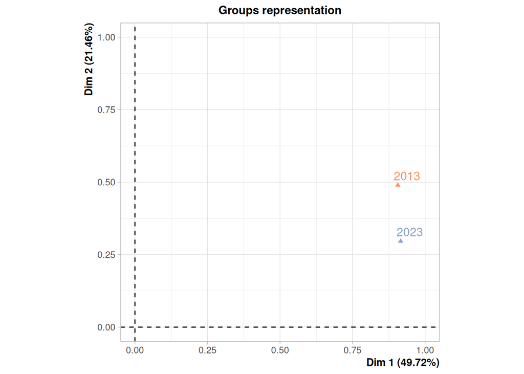

```r
plot(res.MFAprop_horsMayotte, choix = "group", palette = brewer.pal(3, "Set2"))
```